# **Homework #2**

### Author: Skyler Ruiter

### Date: October 17, 2025

### Course: Deep Learning Systems (ENGR-E 533)

# Setup:

Load the needed modules and setup the device for computation.

This homework adds the librosa and soundfile libraries

```python
import torch
from torch.utils.data import DataLoader
import torchvision
import numpy as np
import time
import matplotlib.pyplot as plt
import librosa
import soundfile as sf
from IPython.display import Audio, display

print(torch.cuda.is_available())
device=torch.device('cuda')
if torch.cuda.is_available():
    device = torch.device('cuda')
elif torch.backends.mps.is_available():
    device = torch.device('mps')
else:
    device = torch.device('cpu')
print(device)
```

```
True
cuda
```

```python
# Signal-to-Noise Ratio (SNR) Calculation
def snr(clean, denoised):
    noise = clean - denoised
    snr = 10 * torch.log10(torch.sum(clean ** 2) / torch.sum(noise ** 2))
    return snr
```

Load and format the audio data for training and testing.

```python
# get data
sn, sr = librosa.load('train_clean_male.wav', sr=None)
S = librosa.stft(sn, n_fft=2048, hop_length=512, window='hann')
sn, sr = librosa.load('train_dirty_male.wav', sr=None)
X = librosa.stft(sn, n_fft=2048, hop_length=512, window='hann')
sn, sr = librosa.load('test_x_01.wav', sr=None)
X_test = librosa.stft(sn, n_fft=2048, hop_length=512, window='hann')
sn, sr = librosa.load('test_s_01.wav', sr=None)
S_test = librosa.stft(sn, n_fft=2048, hop_length=512, window='hann')

# pull out magnitudes and phaeses
S_mag = np.abs(S)
S_phase = np.angle(S)
X_mag = np.abs(X)
X_phase = np.angle(X)
X_test_mag = np.abs(X_test)
X_test_phase = np.angle(X_test)
S_test_mag = np.abs(S_test)
S_test_phase = np.angle(S_test)

X_train = torch.tensor(X_mag.T, dtype=torch.float32).to(device)
S_train = torch.tensor(S_mag.T, dtype=torch.float32).to(device)

print(f'S shape: {S_mag.shape}')
print(f'X shape: {X_mag.shape}')
print(f'X_train shape: {X_train.shape}')
print(f'S_train shape: {S_train.shape}')

train_dataset = torch.utils.data.TensorDataset(X_train, S_train)
train_loader = DataLoader(train_dataset, batch_size=64, shuffle=True)

# calc base snr
base_snr = snr(torch.tensor(S_test_mag), torch.tensor(X_test_mag))
print(f'Base SNR: {base_snr:.2f} dB')
```

```
S shape: (1025, 2459)
X shape: (1025, 2459)
X_train shape: torch.Size([2459, 1025])
S_train shape: torch.Size([2459, 1025])
Base SNR: 13.65 dB
```

```python
# plot a spectrogram
def plot_spectrogram(mag, phase, title):
    plt.figure(figsize=(10, 6))
    plt.title(title)
    plt.imshow(20 * np.log10(mag + 1e-6), aspect='auto', origin='lower', cmap='viridis')
    plt.colorbar(label='Magnitude (dB)')
    plt.xlabel('Time Frames')
    plt.ylabel('Frequency Bins')
    plt.show()
```

```
S shape: (1025, 2459)
X shape: (1025, 2459)
```

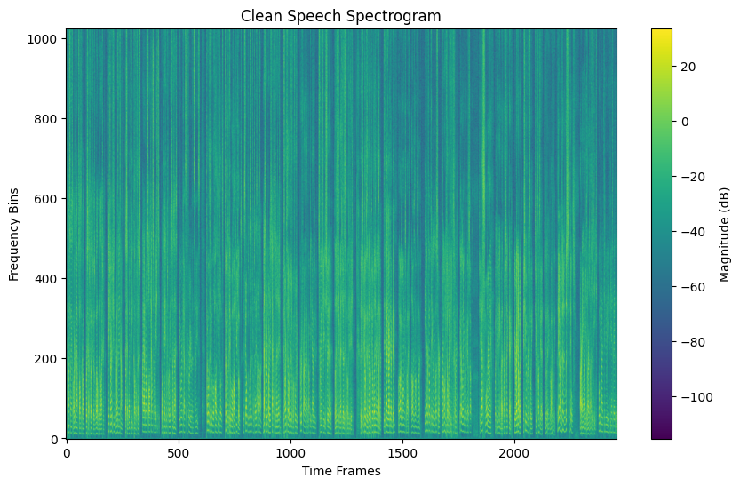

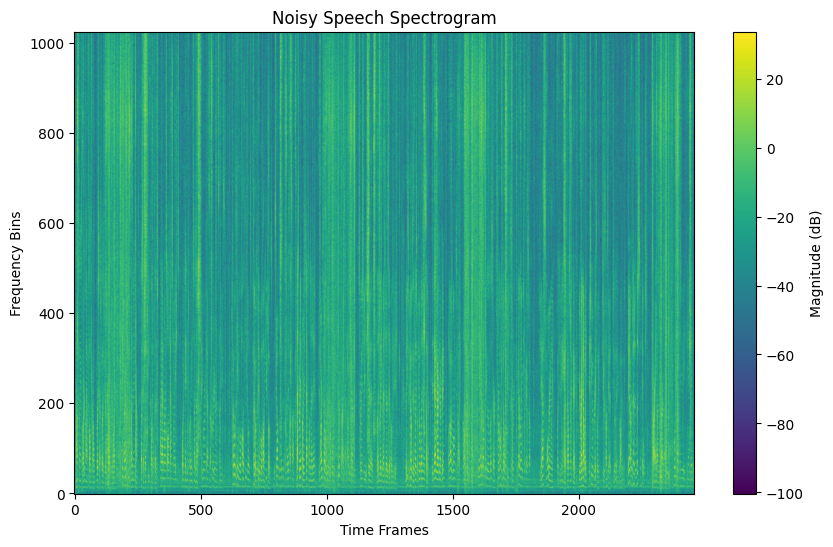

```python
# print dims and spectrogram of S and X
print(f'S shape: {S_mag.shape}')
print(f'X shape: {X_mag.shape}')
plot_spectrogram(S_mag, S_phase, 'Clean Speech Spectrogram')
plot_spectrogram(X_mag, X_phase, 'Noisy Speech Spectrogram')
```

# Problem 1: Speech Denoising Using Deep Learning

I decided to instead of training a network to learn to denoise the speech directly, I trained a network to learn a mask that can be applied to the noisy spectrogram to recover the clean spectrogram.

I thought this approach would result in a model better able to pick out just the chip noise. Combined with the ability to enforce the mask by hand if the chip noise is too loud or to quiet to have some by-hand tuning ability.

```python
class DenoisingDNN(torch.nn.Module):
    def __init__(self, input_dim=1025, hidden_dim=1024):
        super(DenoisingDNN, self).__init__()
        self.network = torch.nn.Sequential(
          torch.nn.Linear(input_dim, hidden_dim),
          torch.nn.PReLU(),
          torch.nn.Dropout(0.2),
          torch.nn.Linear(hidden_dim, hidden_dim),
          torch.nn.PReLU(),
          torch.nn.Dropout(0.2),
          torch.nn.Linear(hidden_dim, input_dim),
          torch.nn.Sigmoid()  # Predict a mask between 0 and 1
        )
        for m in self.network:
            if isinstance(m, torch.nn.Linear):
                torch.nn.init.xavier_uniform_(m.weight)
                torch.nn.init.zeros_(m.bias)

    def forward(self, x):
        mask = self.network(x)
        return x * mask  # Apply mask to input
```

```python
model = DenoisingDNN().to(device)
criterion = torch.nn.MSELoss()
optimizer = torch.optim.Adam(model.parameters(), lr=0.001)
num_epochs = 100
losses = []

for epoch in range(num_epochs):
    epoch_loss = 0.0
    for inputs, targets in train_loader:
      predictions = model(inputs)
      loss = criterion(predictions, targets)
      optimizer.zero_grad()
      loss.backward()
      optimizer.step()
      epoch_loss += loss.item()
    losses.append(epoch_loss / len(train_loader))
    if (epoch + 1) % 10 == 0:
        print(f'Epoch [{epoch + 1}/{num_epochs}], Loss: {epoch_loss / len(train_loader):.4f}')
```

```
Epoch [10/100], Loss: 0.0024
Epoch [20/100], Loss: 0.0019
Epoch [30/100], Loss: 0.0016
Epoch [40/100], Loss: 0.0014
Epoch [50/100], Loss: 0.0012
Epoch [60/100], Loss: 0.0011
Epoch [70/100], Loss: 0.0010
Epoch [80/100], Loss: 0.0010
Epoch [90/100], Loss: 0.0010
Epoch [100/100], Loss: 0.0010
```

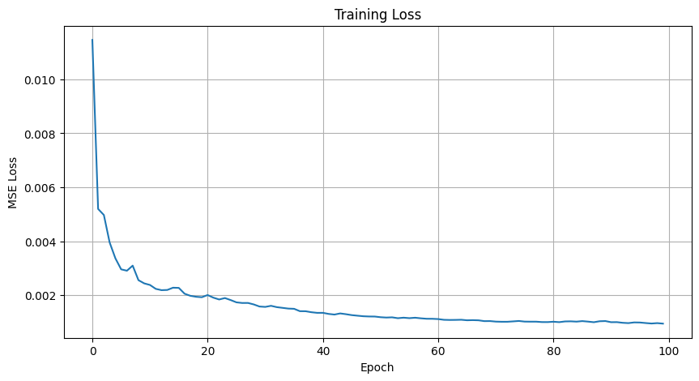

```python
plt.figure(figsize=(10, 5))
plt.plot(losses)
plt.xlabel('Epoch')
plt.ylabel('MSE Loss')
plt.title('Training Loss')
plt.grid(True)
plt.show()
```

For the test data I found good use with 0.3 as the threshold for the mask.

```
Denoised SNR: 13.13 dB
```

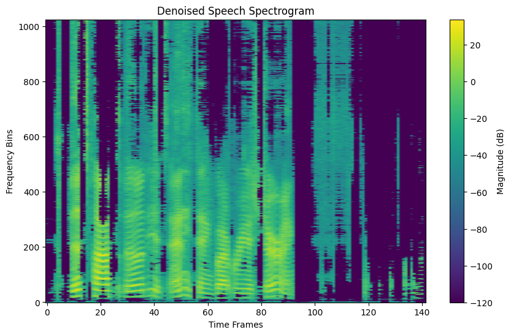

```python
model.eval()
X_test_tensor = torch.tensor(X_test_mag.T, dtype=torch.float32).to(device)
with torch.no_grad():
    denoised_mag_tensor = model(X_test_tensor)

aggressive_threshold = 0.3
mask = (denoised_mag_tensor / (X_test_tensor + 1e-8)).cpu().numpy()
mask_aggressive = np.where(mask < aggressive_threshold, 0, mask)

# Apply aggressive mask
denoised_mag = (X_test_mag.T * mask_aggressive).T

# Reconstruct complex spectrogram using noisy phase
denoised_stft = denoised_mag * np.exp(1j * X_test_phase)
denoised_signal = librosa.istft(denoised_stft, hop_length=512, window='hann')

# Calculate SNR - both should be in same shape (freq, time)
denoised_snr = snr(torch.tensor(S_test_mag), torch.tensor(denoised_mag))
print(f'Denoised SNR: {denoised_snr:.2f} dB')

plot_spectrogram(denoised_mag, X_test_phase, 'Denoised Speech Spectrogram')
sf.write('denoised_output.wav', denoised_signal, sr)
```

```python
display(Audio('denoised_output.wav'))
```

[interactive chart not shown]

Since the chip to voice volume ratio was so much larger I employed a higher mask threshold of 0.8

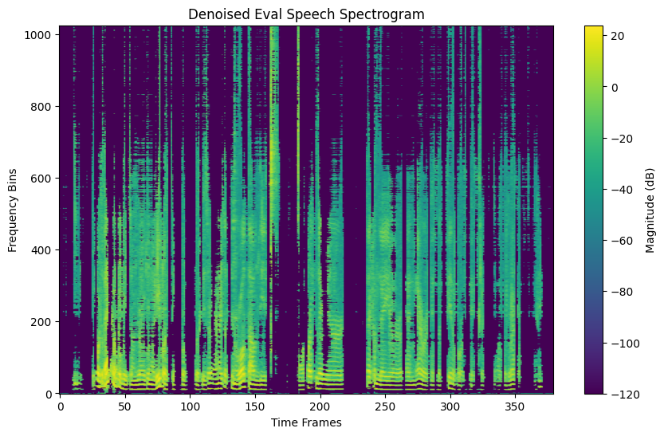

```python
model.eval()
sn, sr = librosa.load('test_x_02.wav', sr=None)
X_eval = librosa.stft(sn, n_fft=2048, hop_length=512, window='hann')
X_eval_mag = np.abs(X_eval)
X_eval_phase = np.angle(X_eval)
X_eval_tensor = torch.tensor(X_eval_mag.T, dtype=torch.float32).to(device)
with torch.no_grad():
    denoised_eval_mag_tensor = model(X_eval_tensor)
aggressive_threshold = 0.8
mask = (denoised_eval_mag_tensor / (X_eval_tensor + 1e-8)).cpu().numpy()
mask_aggressive = np.where(mask < aggressive_threshold, 0, mask)

# Apply aggressive mask
denoised_eval_mag = (X_eval_mag.T * mask_aggressive).T
denoised_eval_stft = denoised_eval_mag * np.exp(1j * X_eval_phase)
denoised_eval_signal = librosa.istft(denoised_eval_stft, hop_length=512, window='hann')
plot_spectrogram(denoised_eval_mag, X_eval_phase, 'Denoised Eval Speech Spectrogram')
sf.write('denoised_eval_output.wav', denoised_eval_signal, sr)
```

```python
display(Audio('denoised_eval_output.wav'))
```

[interactive chart not shown]

# Problem 2: Speech Denoising Using 1D CNN

I liked the mask solution so much from problem 1 that I kept it for problem 2 as well.

```python
class DenoisingCNN(torch.nn.Module):
    def __init__(self, input_dim=1025):
      super(DenoisingCNN, self).__init__()
      # [B, 1, 1025]
      self.conv1 = torch.nn.Conv1d(in_channels=1, out_channels=32, kernel_size=9, stride=2, padding=0)
      self.bn1 = torch.nn.BatchNorm1d(32)
      self.prelu1 = torch.nn.PReLU()
      # [B, 32, (1025-9)/2 + 1 = 509]
      self.conv2 = torch.nn.Conv1d(in_channels=32, out_channels=64, kernel_size=7, stride=2, padding=0)
      self.bn2 = torch.nn.BatchNorm1d(64)
      self.prelu2 = torch.nn.PReLU()
      # [B, 64, (509-7)/2 + 1 = 252]
      self.conv3 = torch.nn.Conv1d(in_channels=64, out_channels=128, kernel_size=5, stride=2, padding=0)
      self.bn3 = torch.nn.BatchNorm1d(128)
      self.prelu3 = torch.nn.PReLU()

      # [B, 128, (252-5)/2 + 1 = 124]

      # flatten and FC layer
      self.fc1 = torch.nn.Linear(128 * 124, 2048)
      self.prelu_fc1 = torch.nn.PReLU()
      self.dropout = torch.nn.Dropout(0.2)
      self.fc2 = torch.nn.Linear(2048, input_dim)
      self.sigmoid = torch.nn.Sigmoid()

      for m in self.modules():
          if isinstance(m, torch.nn.Conv1d) or isinstance(m, torch.nn.Linear):
              torch.nn.init.xavier_uniform_(m.weight)
              torch.nn.init.zeros_(m.bias)

    def forward(self, x):
      x_input = x.unsqueeze(1)  # [B, 1, 1025]
      x_conv = self.prelu1(self.bn1(self.conv1(x_input)))
      x_conv = self.prelu2(self.bn2(self.conv2(x_conv)))
      x_conv = self.prelu3(self.bn3(self.conv3(x_conv)))
      x_flat = x_conv.view(x_conv.size(0), -1)
      x_fc = self.dropout(self.prelu_fc1(self.fc1(x_flat)))
      mask = self.sigmoid(self.fc2(x_fc))
      return x * mask  # Apply mask to input
```

```
CNN Epoch [10/100], Loss: 0.0021
CNN Epoch [20/100], Loss: 0.0015
CNN Epoch [30/100], Loss: 0.0012
CNN Epoch [40/100], Loss: 0.0011
CNN Epoch [50/100], Loss: 0.0009
CNN Epoch [60/100], Loss: 0.0008
CNN Epoch [70/100], Loss: 0.0008
CNN Epoch [80/100], Loss: 0.0007
CNN Epoch [90/100], Loss: 0.0007
CNN Epoch [100/100], Loss: 0.0007
```

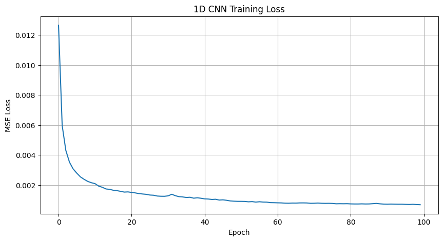

```python
model_cnn = DenoisingCNN().to(device)
criterion_cnn = torch.nn.MSELoss()
optimizer_cnn = torch.optim.Adam(model_cnn.parameters(), lr=0.001)

num_epochs_cnn = 100
losses_cnn = []

for epoch in range(num_epochs_cnn):
    epoch_loss = 0.0
    for inputs, targets in train_loader:
      predictions = model_cnn(inputs)
      loss = criterion_cnn(predictions, targets)
      optimizer_cnn.zero_grad()
      loss.backward()
      optimizer_cnn.step()
      epoch_loss += loss.item()
    losses_cnn.append(epoch_loss / len(train_loader))
    if (epoch + 1) % 10 == 0:
        print(f'CNN Epoch [{epoch + 1}/{num_epochs_cnn}], Loss: {epoch_loss / len(train_loader):.4f}')

# Plot CNN training loss
plt.figure(figsize=(10, 5))
plt.plot(losses_cnn)
plt.xlabel('Epoch')
plt.ylabel('MSE Loss')
plt.title('1D CNN Training Loss')
plt.grid(True)
plt.show()
```

```
1D CNN Denoised SNR: 14.43 dB
```

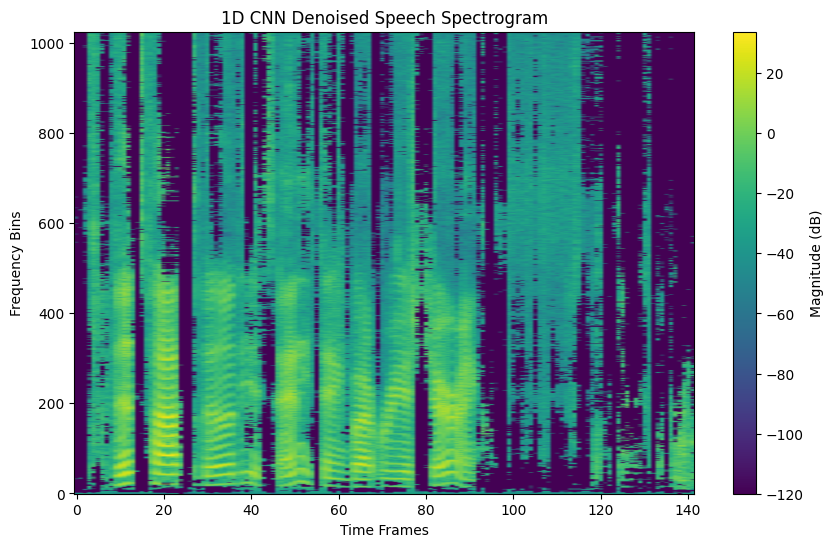

```python
model.eval()
X_test_tensor = torch.tensor(X_test_mag.T, dtype=torch.float32).to(device)

with torch.no_grad():
    denoised_mag_tensor_cnn = model_cnn(X_test_tensor)

# Apply aggressive thresholding
aggressive_threshold_cnn = 0.3
mask_cnn = (denoised_mag_tensor_cnn / (X_test_tensor + 1e-8)).cpu().numpy()
mask_aggressive_cnn = np.where(mask_cnn < aggressive_threshold_cnn, 0, mask_cnn)

# Apply mask
denoised_mag_cnn = (X_test_mag.T * mask_aggressive_cnn).T

# Reconstruct signal
denoised_stft_cnn = denoised_mag_cnn * np.exp(1j * X_test_phase)
denoised_signal_cnn = librosa.istft(denoised_stft_cnn, hop_length=512, window='hann')

# Calculate SNR
denoised_snr_cnn = snr(torch.tensor(S_test_mag), torch.tensor(denoised_mag_cnn))
print(f'1D CNN Denoised SNR: {denoised_snr_cnn:.2f} dB')

# Plot spectrogram
plot_spectrogram(denoised_mag_cnn, X_test_phase, '1D CNN Denoised Speech Spectrogram')

# Save audio
sf.write('denoised_cnn_output.wav', denoised_signal_cnn, sr)
```

```python
display(Audio('denoised_cnn_output.wav'))
```

[interactive chart not shown]

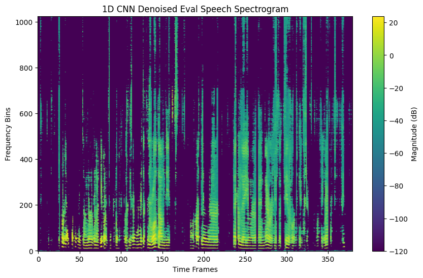

```python
# now on test_02.wav
model_cnn.eval()
sn, sr = librosa.load('test_x_02.wav', sr=None)
X_eval = librosa.stft(sn, n_fft=2048, hop_length=512, window='hann')
X_eval_mag = np.abs(X_eval)
X_eval_phase = np.angle(X_eval)
X_eval_tensor = torch.tensor(X_eval_mag.T, dtype=torch.float32).to(device)
with torch.no_grad():
    denoised_eval_mag_tensor_cnn = model_cnn(X_eval_tensor)
aggressive_threshold_cnn = 0.8
mask_cnn = (denoised_eval_mag_tensor_cnn / (X_eval_tensor + 1e-8)).cpu().numpy()
mask_aggressive_cnn = np.where(mask_cnn < aggressive_threshold_cnn, 0, mask_cnn)

# Apply aggressive mask
denoised_eval_mag_cnn = (X_eval_mag.T * mask_aggressive_cnn).T
denoised_eval_stft_cnn = denoised_eval_mag_cnn * np.exp(1j * X_eval_phase)
denoised_eval_signal_cnn = librosa.istft(denoised_eval_stft_cnn, hop_length=512, window='hann')
plot_spectrogram(denoised_eval_mag_cnn, X_eval_phase, '1D CNN Denoised Eval Speech Spectrogram')
sf.write('denoised_eval_cnn_output.wav', denoised_eval_signal_cnn, sr)
```

```python
display(Audio('denoised_eval_cnn_output.wav'))
```

[interactive chart not shown]

# Problem 3: Data Augmentation

```python
def unpickle(file):
    import pickle
    with open(file, 'rb') as fo:
        dict = pickle.load(fo, encoding='bytes')
    return dict

train_data = []
train_labels = []

for i in range(1, 6):  # 5 training batches
    batch_file = f'cifar-10-batches-py/data_batch_{i}'
    batch_dict = unpickle(batch_file)
    train_data.append(batch_dict[b'data'])
    train_labels.extend(batch_dict[b'labels'])

train_data = np.concatenate(train_data, axis=0)
train_labels = np.array(train_labels)

test_dict = unpickle('cifar-10-batches-py/test_batch')
test_data = test_dict[b'data']
test_labels = np.array(test_dict[b'labels'])

train_data = train_data.reshape(-1, 3, 32, 32)
test_data = test_data.reshape(-1, 3, 32, 32)

# 45000 for training, 5000 for validation
val_size = 5000
indices = np.random.permutation(len(train_data))
train_indices = indices[val_size:]
val_indices = indices[:val_size]

X_train = train_data[train_indices]
y_train = train_labels[train_indices]
X_val = train_data[val_indices]
y_val = train_labels[val_indices]

X_train_tensor = torch.tensor(X_train, dtype=torch.float32).to(device)
y_train_tensor = torch.tensor(y_train, dtype=torch.long).to(device)
X_val_tensor = torch.tensor(X_val, dtype=torch.float32).to(device)
y_val_tensor = torch.tensor(y_val, dtype=torch.long).to(device)
X_test_tensor = torch.tensor(test_data, dtype=torch.float32).to(device)
y_test_tensor = torch.tensor(test_labels, dtype=torch.long).to(device)

# Scale from (0, 255) to (0, 1)
X_train_tensor = X_train_tensor / 255.0
X_val_tensor = X_val_tensor / 255.0
X_test_tensor = X_test_tensor / 255.0

# Rescale from (0, 1) to (-1, 1)
X_train_tensor = X_train_tensor * 2 - 1
X_val_tensor = X_val_tensor * 2 - 1
X_test_tensor = X_test_tensor * 2 - 1

train_dataset_cifar = torch.utils.data.TensorDataset(X_train_tensor, y_train_tensor)
val_dataset_cifar = torch.utils.data.TensorDataset(X_val_tensor, y_val_tensor)
test_dataset_cifar = torch.utils.data.TensorDataset(X_test_tensor, y_test_tensor)

train_loader_cifar = DataLoader(train_dataset_cifar, batch_size=128, shuffle=True)
val_loader_cifar = DataLoader(val_dataset_cifar, batch_size=128, shuffle=False)
test_loader_cifar = DataLoader(test_dataset_cifar, batch_size=128, shuffle=False)

print(f'Training samples: {len(X_train)}')
print(f'Validation samples: {len(X_val)}')
print(f'Test samples: {len(test_data)}')
print(f'Image shape: {X_train.shape[1:]}')
print(f'Number of classes: {len(np.unique(train_labels))}')
print(f'Data range: [{X_train_tensor.min():.2f}, {X_train_tensor.max():.2f}]')
```

```
Training samples: 45000
Validation samples: 5000
Test samples: 10000
Image shape: (3, 32, 32)
Number of classes: 10
Data range: [-1.00, 1.00]
```

I define a single CNN class which does classification for the following two problems.

For the images we need the 10 classes but for the pretext we only use 3 classes.

specifications are as given in the assignment.

```python
class ClassifierCNN(torch.nn.Module):
  def __init__(self, num_classes=10):
    super(ClassifierCNN, self).__init__()
    # input = [B, 3, 32, 32]
    self.conv1 = torch.nn.Conv2d(in_channels=3, out_channels=10, kernel_size=5, stride=1, padding=0)
    # output = [B, 10, 28, 28]
    self.pool1 = torch.nn.MaxPool2d(kernel_size=2, stride=2)
    # output = [B, 10, 14, 14]
    self.conv2 = torch.nn.Conv2d(in_channels=10, out_channels=10, kernel_size=5, stride=1, padding=0)
    # output = [B, 10, 10, 10]
    self.pool2 = torch.nn.MaxPool2d(kernel_size=2, stride=2)
    # output = [B, 10, 5, 5]
    self.fc1 = torch.nn.Linear(10 * 5 * 5, 20)
    self.fc2 = torch.nn.Linear(20, num_classes)
    self.relu = torch.nn.ReLU()
    # init weights with He
    for m in self.modules():
        if isinstance(m, torch.nn.Conv2d) or isinstance(m, torch.nn.Linear):
            torch.nn.init.kaiming_uniform_(m.weight, nonlinearity='relu')
            torch.nn.init.zeros_(m.bias)
  def forward(self, x):
    x = self.relu(self.conv1(x))
    x = self.pool1(x)
    x = self.relu(self.conv2(x))
    x = self.pool2(x)
    x = x.view(x.size(0), -1)
    x = self.relu(self.fc1(x))
    x = self.fc2(x)
    return x
```

```python
model_cifar_cnn = ClassifierCNN().to(device)
criterion_cifar = torch.nn.CrossEntropyLoss()
optimizer_cifar = torch.optim.Adam(model_cifar_cnn.parameters(), lr=0.001)
num_epochs_cifar = 200
losses_cifar = []
losses_val_cifar = []

for epoch in range(num_epochs_cifar):
    epoch_loss = 0.0
    model_cifar_cnn.train()
    for inputs, targets in train_loader_cifar:
      predictions = model_cifar_cnn(inputs)
      loss = criterion_cifar(predictions, targets)
      optimizer_cifar.zero_grad()
      loss.backward()
      optimizer_cifar.step()
      epoch_loss += loss.item()
    losses_cifar.append(epoch_loss / len(train_loader_cifar))
    if (epoch + 1) % 10 == 0:
        print(f'CIFAR CNN Epoch [{epoch + 1}/{num_epochs_cifar}], Loss: {epoch_loss / len(train_loader_cifar):.4f}')

    # Validation loss
    model_cifar_cnn.eval()
    correct = 0
    total = 0
    with torch.no_grad():
      for inputs, labels in val_loader_cifar:
        outputs = model_cifar_cnn(inputs)
        _, predicted = torch.max(outputs.data, 1)
        total += labels.size(0)
        correct += (predicted == labels).sum().item()
    val_accuracy = 100 * correct / total
    losses_val_cifar.append(val_accuracy)
```

```
CIFAR CNN Epoch [10/200], Loss: 1.1544
CIFAR CNN Epoch [20/200], Loss: 1.0389
CIFAR CNN Epoch [30/200], Loss: 0.9818
CIFAR CNN Epoch [40/200], Loss: 0.9395
CIFAR CNN Epoch [50/200], Loss: 0.9136
CIFAR CNN Epoch [60/200], Loss: 0.8922
CIFAR CNN Epoch [70/200], Loss: 0.8712
CIFAR CNN Epoch [80/200], Loss: 0.8587
CIFAR CNN Epoch [90/200], Loss: 0.8472
CIFAR CNN Epoch [100/200], Loss: 0.8369
CIFAR CNN Epoch [110/200], Loss: 0.8308
CIFAR CNN Epoch [120/200], Loss: 0.8230
CIFAR CNN Epoch [130/200], Loss: 0.8150
CIFAR CNN Epoch [140/200], Loss: 0.8112
CIFAR CNN Epoch [150/200], Loss: 0.8056
CIFAR CNN Epoch [160/200], Loss: 0.7984
CIFAR CNN Epoch [170/200], Loss: 0.7983
CIFAR CNN Epoch [180/200], Loss: 0.7897
CIFAR CNN Epoch [190/200], Loss: 0.7831
CIFAR CNN Epoch [200/200], Loss: 0.7776
```

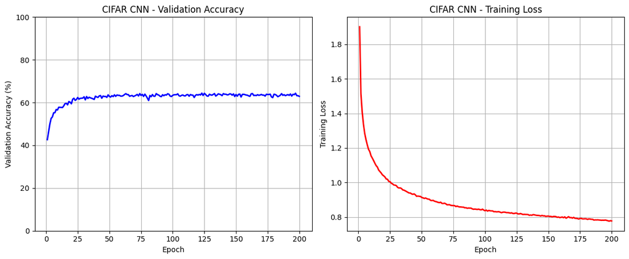

```python
plt.figure(figsize=(12, 5))

plt.subplot(1, 2, 1)
plt.plot(range(1, num_epochs_cifar + 1), losses_val_cifar, 'b-', linewidth=2)
plt.xlabel('Epoch')
plt.ylabel('Validation Accuracy (%)')
plt.title('CIFAR CNN - Validation Accuracy')
plt.grid(True)
plt.ylim([0, 100])

plt.subplot(1, 2, 2)
plt.plot(range(1, num_epochs_cifar + 1), losses_cifar, 'r-', linewidth=2)
plt.xlabel('Epoch')
plt.ylabel('Training Loss')
plt.title('CIFAR CNN - Training Loss')
plt.grid(True)

plt.tight_layout()
plt.show()
```

Augmenting the dataset:

```python
X_train_01 = (X_train_tensor + 1) / 2.0 # back to (0, 1) range

# dataset 1 -- 10% brighter
X_train_brightened = torch.minimum(X_train_01 * 1.1, torch.ones_like(X_train_01))

# dataset 2 -- 10% darker
X_train_darkened = X_train_01 * 0.9

# dataset 3 -- horizontal flip
X_train_flipped = torch.flip(X_train_01, dims=[3])

# dataset 4 -- original
X_train_original = X_train_01.clone()

# Combine all datasets
X_train_augmented = torch.cat([X_train_brightened, X_train_darkened, X_train_flipped, X_train_original], dim=0)
y_train_augmented = torch.cat([y_train_tensor, y_train_tensor, y_train_tensor, y_train_tensor], dim=0)

# scale back to (-1, 1)
X_train_augmented = X_train_augmented * 2.0 - 1.0

train_dataset_augmented = torch.utils.data.TensorDataset(X_train_augmented, y_train_augmented)
train_loader_augmented = DataLoader(train_dataset_augmented, batch_size=128, shuffle=True)

print(f'Original training samples: {len(X_train_tensor)}')
print(f'Augmented training samples: {len(X_train_augmented)}')
print(f'Augmentation factor: {len(X_train_augmented) / len(X_train_tensor):.1f}x')
print(f'Augmented data range: [{X_train_augmented.min():.2f}, {X_train_augmented.max():.2f}]')
```

```
Original training samples: 45000
Augmented training samples: 180000
Augmentation factor: 4.0x
```

```
Augmented data range: [-1.00, 1.00]
```

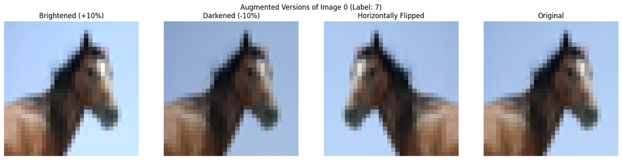

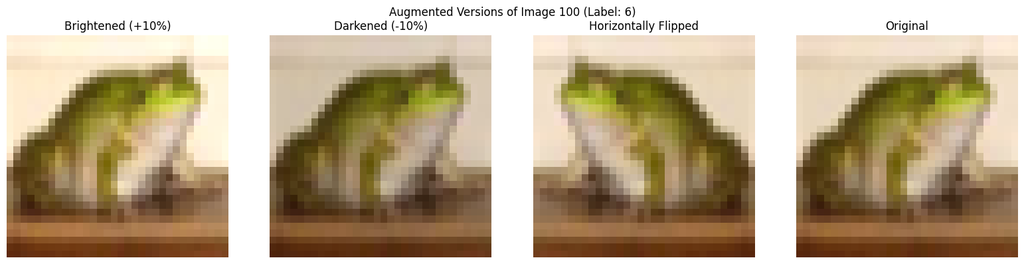

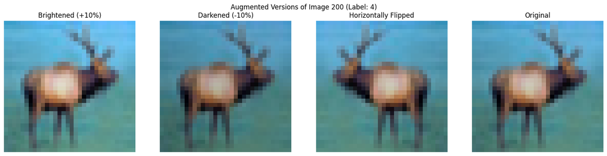

```python
def visualize_augmentations(idx=0):
    """Visualize the 4 versions of a single image"""
    fig, axes = plt.subplots(1, 4, figsize=(16, 4))

    # Get the same image from each augmented dataset (they're concatenated)
    n = len(y_train_tensor)

    # Convert back to [0, 255] for visualization
    img_bright = ((X_train_augmented[idx].cpu() + 1) / 2.0).numpy().transpose(1, 2, 0)
    img_dark = ((X_train_augmented[idx + n].cpu() + 1) / 2.0).numpy().transpose(1, 2, 0)
    img_flip = ((X_train_augmented[idx + 2*n].cpu() + 1) / 2.0).numpy().transpose(1, 2, 0)
    img_original = ((X_train_augmented[idx + 3*n].cpu() + 1) / 2.0).numpy().transpose(1, 2, 0)

    axes[0].imshow(img_bright)
    axes[0].set_title('Brightened (+10%)')
    axes[0].axis('off')

    axes[1].imshow(img_dark)
    axes[1].set_title('Darkened (-10%)')
    axes[1].axis('off')

    axes[2].imshow(img_flip)
    axes[2].set_title('Horizontally Flipped')
    axes[2].axis('off')

    axes[3].imshow(img_original)
    axes[3].set_title('Original')
    axes[3].axis('off')

    plt.suptitle(f'Augmented Versions of Image {idx} (Label: {y_train_augmented[idx].item()})')
    plt.tight_layout()
    plt.show()

# Visualize a few examples
for i in range(3):
    visualize_augmentations(idx=i*100)
```

```python
model_augmented = ClassifierCNN().to(device)
criterion_augmented = torch.nn.CrossEntropyLoss()
optimizer_augmented = torch.optim.Adam(model_augmented.parameters(), lr=0.001)
num_epochs_augmented = 200
losses_augmented = []
val_accuracies_augmented = []

for epoch in range(num_epochs_augmented):
    epoch_loss = 0.0
    model_augmented.train()
    for inputs, targets in train_loader_augmented:
      predictions = model_augmented(inputs)
      loss = criterion_augmented(predictions, targets)
      optimizer_augmented.zero_grad()
      loss.backward()
      optimizer_augmented.step()
      epoch_loss += loss.item()
    losses_augmented.append(epoch_loss / len(train_loader_augmented))
    if (epoch + 1) % 10 == 0:
        print(f'Augmented CIFAR CNN Epoch [{epoch + 1}/{num_epochs_augmented}], Loss: {epoch_loss / len(train_loader_augmented):.4f}')

    # Validation loss
    model_augmented.eval()
    correct = 0
    total = 0
    with torch.no_grad():
      for inputs, labels in val_loader_cifar:
        outputs = model_augmented(inputs)
        _, predicted = torch.max(outputs.data, 1)
        total += labels.size(0)
        correct += (predicted == labels).sum().item()
    val_accuracy = 100 * correct / total
    val_accuracies_augmented.append(val_accuracy)
```

```
Augmented CIFAR CNN Epoch [10/200], Loss: 0.9365
Augmented CIFAR CNN Epoch [20/200], Loss: 0.8631
Augmented CIFAR CNN Epoch [30/200], Loss: 0.8321
Augmented CIFAR CNN Epoch [40/200], Loss: 0.8113
Augmented CIFAR CNN Epoch [50/200], Loss: 0.7990
Augmented CIFAR CNN Epoch [60/200], Loss: 0.7873
Augmented CIFAR CNN Epoch [70/200], Loss: 0.7791
Augmented CIFAR CNN Epoch [80/200], Loss: 0.7745
Augmented CIFAR CNN Epoch [90/200], Loss: 0.7694
Augmented CIFAR CNN Epoch [100/200], Loss: 0.7662
Augmented CIFAR CNN Epoch [110/200], Loss: 0.7631
Augmented CIFAR CNN Epoch [120/200], Loss: 0.7584
Augmented CIFAR CNN Epoch [130/200], Loss: 0.7575
Augmented CIFAR CNN Epoch [140/200], Loss: 0.7533
Augmented CIFAR CNN Epoch [150/200], Loss: 0.7487
Augmented CIFAR CNN Epoch [160/200], Loss: 0.7489
Augmented CIFAR CNN Epoch [170/200], Loss: 0.7466
Augmented CIFAR CNN Epoch [180/200], Loss: 0.7441
Augmented CIFAR CNN Epoch [190/200], Loss: 0.7433
Augmented CIFAR CNN Epoch [200/200], Loss: 0.7419
```

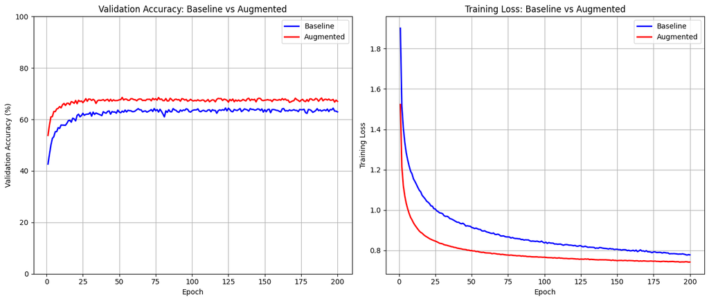

```
============================================================
PERFORMANCE COMPARISON
============================================================
Baseline - Final Validation Accuracy: 62.92%
Augmented - Final Validation Accuracy: 67.00%
Improvement: +4.08%
============================================================
```

```python
plt.figure(figsize=(14, 6))

plt.subplot(1, 2, 1)
plt.plot(range(1, len(losses_val_cifar) + 1), losses_val_cifar, 'b-', linewidth=2, label='Baseline')
plt.plot(range(1, len(val_accuracies_augmented) + 1), val_accuracies_augmented, 'r-', linewidth=2, label='Augmented')
plt.xlabel('Epoch')
plt.ylabel('Validation Accuracy (%)')
plt.title('Validation Accuracy: Baseline vs Augmented')
plt.legend()
plt.grid(True)
plt.ylim([0, 100])

plt.subplot(1, 2, 2)
plt.plot(range(1, len(losses_cifar) + 1), losses_cifar, 'b-', linewidth=2, label='Baseline')
plt.plot(range(1, len(losses_augmented) + 1), losses_augmented, 'r-', linewidth=2, label='Augmented')
plt.xlabel('Epoch')
plt.ylabel('Training Loss')
plt.title('Training Loss: Baseline vs Augmented')
plt.legend()
plt.grid(True)

plt.tight_layout()
plt.show()

# Print summary statistics
print("\n" + "="*60)
print("PERFORMANCE COMPARISON")
print("="*60)
print(f"Baseline - Final Validation Accuracy: {losses_val_cifar[-1]:.2f}%")
print(f"Augmented - Final Validation Accuracy: {val_accuracies_augmented[-1]:.2f}%")
print(f"Improvement: {val_accuracies_augmented[-1] - losses_val_cifar[-1]:+.2f}%")
print("="*60)
```

The augmented dataset did help the model learn better features for the image classification task.

The improvements were not huge but demonstrate that the augmentations helped the model generalize better on this difficult task.

# Problem 4: Self-Supervised Learning via Pretext Tasks

```python
# step 1 and 2: subsample dataset
num_labeled = 50 # per class
total_labeled = num_labeled * 10 # 500 total

X_labeled = X_train_tensor[-total_labeled:]
y_labeled = y_train_tensor[-total_labeled:]

X_unlabeled = X_train_tensor[:-total_labeled]
y_unlabeled_orig = y_train_tensor[:-total_labeled]  # ignored

print(f'Labeled dataset size: {len(X_labeled)}')
print(f'Unlabeled dataset size: {len(X_unlabeled)}')
print(f'Labeled data range: [{X_labeled.min():.2f}, {X_labeled.max():.2f}]')
```

```
Labeled dataset size: 500
Unlabeled dataset size: 44500
Labeled data range: [-1.00, 1.00]
```

```python
# step 3: create pretext task dataset

# class 0
X_pretext_class0 = X_unlabeled.clone()
y_pretext_class0 = torch.zeros(len(X_unlabeled), dtype=torch.long).to(device)

# class 1
X_pretext_class1 = torch.flip(X_unlabeled, dims=[2]) # vertical flip
y_pretext_class1 = torch.ones(len(X_unlabeled), dtype=torch.long).to(device)

# class 2
X_pretext_class2 = torch.rot90(X_unlabeled, k=1, dims=[2,3]) # rotate 90 degrees
y_pretext_class2 = torch.full((len(X_unlabeled),), 2, dtype=torch.long).to(device)

# combine classes
X_pretext = torch.cat([X_pretext_class0, X_pretext_class1, X_pretext_class2], dim=0)
y_pretext = torch.cat([y_pretext_class0, y_pretext_class1, y_pretext_class2], dim=0)

print(f'Pretext dataset size: {len(X_pretext)} ({len(X_unlabeled)} per class x 3 classes)')
print(f'Pretext labels distribution: {torch.bincount(y_pretext)}')

# Create pretext dataloader
pretext_dataset = torch.utils.data.TensorDataset(X_pretext, y_pretext)
pretext_loader = DataLoader(pretext_dataset, batch_size=128, shuffle=True)
```

```
Pretext dataset size: 133500 (44500 per class x 3 classes)
Pretext labels distribution: tensor([44500, 44500, 44500], device='cuda:0')
```

```python
model_pretext = ClassifierCNN(num_classes=3).to(device)
criterion_pretext = torch.nn.CrossEntropyLoss()
optimizer_pretext = torch.optim.Adam(model_pretext.parameters(), lr=0.001)
num_epochs_pretext = 200
losses_pretext = []
for epoch in range(num_epochs_pretext):
    epoch_loss = 0.0
    model_pretext.train()
    for inputs, targets in pretext_loader:
      predictions = model_pretext(inputs)
      loss = criterion_pretext(predictions, targets)
      optimizer_pretext.zero_grad()
      loss.backward()
      optimizer_pretext.step()
      epoch_loss += loss.item()
    losses_pretext.append(epoch_loss / len(pretext_loader))
    if (epoch + 1) % 10 == 0:
        print(f'Pretext Task Epoch [{epoch + 1}/{num_epochs_pretext}], Loss: {epoch_loss / len(pretext_loader):.4f}')

torch.save(model_pretext.state_dict(), 'pretext_cnn.pth')
```

```
Pretext Task Epoch [10/200], Loss: 0.6169
```

```
Pretext Task Epoch [20/200], Loss: 0.5799
Pretext Task Epoch [30/200], Loss: 0.5615
Pretext Task Epoch [40/200], Loss: 0.5501
Pretext Task Epoch [50/200], Loss: 0.5455
Pretext Task Epoch [60/200], Loss: 0.5380
Pretext Task Epoch [70/200], Loss: 0.5325
Pretext Task Epoch [80/200], Loss: 0.5287
Pretext Task Epoch [90/200], Loss: 0.5256
Pretext Task Epoch [100/200], Loss: 0.5216
Pretext Task Epoch [110/200], Loss: 0.5209
Pretext Task Epoch [120/200], Loss: 0.5182
Pretext Task Epoch [130/200], Loss: 0.5170
Pretext Task Epoch [140/200], Loss: 0.5156
Pretext Task Epoch [150/200], Loss: 0.5136
Pretext Task Epoch [160/200], Loss: 0.5115
Pretext Task Epoch [170/200], Loss: 0.5108
Pretext Task Epoch [180/200], Loss: 0.5092
Pretext Task Epoch [190/200], Loss: 0.5095
Pretext Task Epoch [200/200], Loss: 0.5071
```

Baseline Training:

```python
labeled_dataset = torch.utils.data.TensorDataset(X_labeled, y_labeled)
labeled_loader = DataLoader(labeled_dataset, batch_size=64, shuffle=True)

model_baseline = ClassifierCNN().to(device)
criterion_baseline = torch.nn.CrossEntropyLoss()
optimizer_baseline = torch.optim.Adam(model_baseline.parameters(), lr=0.001)

# train baseline from scratch
num_epochs_baseline = 10000
test_accuracies_baseline = []

for epoch in range(num_epochs_baseline):
    epoch_loss = 0.0
    model_baseline.train()
    for inputs, targets in labeled_loader:
      predictions = model_baseline(inputs)
      loss = criterion_baseline(predictions, targets)
      optimizer_baseline.zero_grad()
      loss.backward()
      optimizer_baseline.step()
    # Check test accuracy every 100 epochs
    if (epoch + 1) % 100 == 0:
        model_baseline.eval()
        correct = 0
        total = 0
        with torch.no_grad():
            for inputs, labels in test_loader_cifar:
                outputs = model_baseline(inputs)
                _, predicted = torch.max(outputs.data, 1)
                total += labels.size(0)
                correct += (predicted == labels).sum().item()

        test_accuracy = 100 * correct / total
        test_accuracies_baseline.append(test_accuracy)
        print(f'Baseline Epoch [{epoch + 1}/{num_epochs_baseline}], Test Accuracy: {test_accuracy:.2f}%')

print(f'\nBaseline Final Test Accuracy: {test_accuracies_baseline[-1]:.2f}%')
```

```
Baseline Epoch [100/10000], Test Accuracy: 30.50%
Baseline Epoch [200/10000], Test Accuracy: 30.76%
Baseline Epoch [300/10000], Test Accuracy: 30.72%
Baseline Epoch [400/10000], Test Accuracy: 30.62%
Baseline Epoch [500/10000], Test Accuracy: 30.59%
Baseline Epoch [600/10000], Test Accuracy: 30.57%
Baseline Epoch [700/10000], Test Accuracy: 30.56%
Baseline Epoch [800/10000], Test Accuracy: 30.61%
Baseline Epoch [900/10000], Test Accuracy: 30.74%
Baseline Epoch [1000/10000], Test Accuracy: 30.74%
Baseline Epoch [1100/10000], Test Accuracy: 30.77%
Baseline Epoch [1200/10000], Test Accuracy: 30.66%
Baseline Epoch [1300/10000], Test Accuracy: 30.71%
Baseline Epoch [1400/10000], Test Accuracy: 30.67%
Baseline Epoch [1500/10000], Test Accuracy: 30.64%
Baseline Epoch [1600/10000], Test Accuracy: 30.61%
Baseline Epoch [1700/10000], Test Accuracy: 30.61%
Baseline Epoch [1800/10000], Test Accuracy: 30.57%
Baseline Epoch [1900/10000], Test Accuracy: 30.56%
Baseline Epoch [2000/10000], Test Accuracy: 30.61%
Baseline Epoch [2100/10000], Test Accuracy: 30.57%
Baseline Epoch [2200/10000], Test Accuracy: 30.48%
Baseline Epoch [2300/10000], Test Accuracy: 30.47%
Baseline Epoch [2400/10000], Test Accuracy: 30.22%
Baseline Epoch [2500/10000], Test Accuracy: 29.97%
Baseline Epoch [2600/10000], Test Accuracy: 29.98%
Baseline Epoch [2700/10000], Test Accuracy: 30.13%
Baseline Epoch [2800/10000], Test Accuracy: 29.40%
Baseline Epoch [2900/10000], Test Accuracy: 29.23%
Baseline Epoch [3000/10000], Test Accuracy: 29.16%
Baseline Epoch [3100/10000], Test Accuracy: 29.17%
Baseline Epoch [3200/10000], Test Accuracy: 29.18%
Baseline Epoch [3300/10000], Test Accuracy: 29.39%
Baseline Epoch [3400/10000], Test Accuracy: 29.34%
Baseline Epoch [3500/10000], Test Accuracy: 29.42%
Baseline Epoch [3600/10000], Test Accuracy: 29.40%
Baseline Epoch [3700/10000], Test Accuracy: 29.47%
Baseline Epoch [3800/10000], Test Accuracy: 29.52%
Baseline Epoch [3900/10000], Test Accuracy: 29.71%
Baseline Epoch [4000/10000], Test Accuracy: 29.74%
```

[output cut: 47 more lines]

```
Baseline Epoch [8800/10000], Test Accuracy: 28.85%
Baseline Epoch [8900/10000], Test Accuracy: 28.80%
Baseline Epoch [9000/10000], Test Accuracy: 28.79%
Baseline Epoch [9100/10000], Test Accuracy: 28.79%
Baseline Epoch [9200/10000], Test Accuracy: 28.87%
Baseline Epoch [9300/10000], Test Accuracy: 28.87%
Baseline Epoch [9400/10000], Test Accuracy: 28.96%
Baseline Epoch [9500/10000], Test Accuracy: 28.99%
Baseline Epoch [9600/10000], Test Accuracy: 29.01%
Baseline Epoch [9700/10000], Test Accuracy: 29.02%
Baseline Epoch [9800/10000], Test Accuracy: 29.12%
Baseline Epoch [9900/10000], Test Accuracy: 29.11%
Baseline Epoch [10000/10000], Test Accuracy: 29.15%

Baseline Final Test Accuracy: 29.15%
```

Transfer Learning Training:

Assignment didn't specify if to treat the entire fully connected section as the "last layer" or just the final final layer. I didn't think it made a ton of sense to transfer the first fully connected layer since I don't think its learning the features well (at least in my testing leaving it untransferred led to better results). So I left the entire fully connected section untransferred.

```python
# transfer learning
model_transfer = ClassifierCNN().to(device)

pretext_state_dict = torch.load('pretext_cnn.pth')

transfer_dict = {}
for name, param in pretext_state_dict.items():
    if 'fc1' not in name and 'fc2' not in name:
        transfer_dict[name] = param

model_transfer.load_state_dict(transfer_dict, strict=False)

# then init final layer with He
torch.nn.init.kaiming_uniform_(model_transfer.fc1.weight, nonlinearity='relu')
torch.nn.init.zeros_(model_transfer.fc1.bias)
torch.nn.init.kaiming_uniform_(model_transfer.fc2.weight, nonlinearity='relu')
torch.nn.init.zeros_(model_transfer.fc2.bias)

transferred_params = []
new_params = []

for name, param in model_transfer.named_parameters():
    if 'fc2' in name or 'fc1' in name:
        new_params.append(param)
    else:
        transferred_params.append(param)

optimizer_transfer = torch.optim.Adam([
    {'params': transferred_params, 'lr': 1e-6},
    {'params': new_params, 'lr': 1e-3}
])

criterion_transfer = torch.nn.CrossEntropyLoss()

num_epochs_transfer = 10000
test_accuracies_transfer = []

for epoch in range(num_epochs_transfer):
    epoch_loss = 0.0
    model_transfer.train()
    for inputs, targets in labeled_loader:
        predictions = model_transfer(inputs)
        loss = criterion_transfer(predictions, targets)
        optimizer_transfer.zero_grad()
        loss.backward()
        optimizer_transfer.step()

    # Check test accuracy every 100 epochs
    if (epoch + 1) % 100 == 0:
        model_transfer.eval()
        correct = 0
        total = 0
        with torch.no_grad():
            for inputs, labels in test_loader_cifar:
                outputs = model_transfer(inputs)
                _, predicted = torch.max(outputs.data, 1)
                total += labels.size(0)
                correct += (predicted == labels).sum().item()

        test_accuracy = 100 * correct / total
        test_accuracies_transfer.append(test_accuracy)
        print(f'Transfer Epoch [{epoch + 1}/{num_epochs_transfer}], Test Accuracy: {test_accuracy:.2f}%')

print(f'\nTransfer Learning Final Test Accuracy: {test_accuracies_transfer[-1]:.2f}%')
```

```
Transfer Epoch [100/10000], Test Accuracy: 29.00%
Transfer Epoch [200/10000], Test Accuracy: 30.86%
Transfer Epoch [300/10000], Test Accuracy: 30.52%
Transfer Epoch [400/10000], Test Accuracy: 30.49%
Transfer Epoch [500/10000], Test Accuracy: 30.16%
Transfer Epoch [600/10000], Test Accuracy: 30.38%
Transfer Epoch [700/10000], Test Accuracy: 30.28%
Transfer Epoch [800/10000], Test Accuracy: 30.02%
Transfer Epoch [900/10000], Test Accuracy: 30.15%
Transfer Epoch [1000/10000], Test Accuracy: 30.36%
Transfer Epoch [1100/10000], Test Accuracy: 30.43%
Transfer Epoch [1200/10000], Test Accuracy: 30.30%
Transfer Epoch [1300/10000], Test Accuracy: 30.30%
Transfer Epoch [1400/10000], Test Accuracy: 30.40%
Transfer Epoch [1500/10000], Test Accuracy: 30.20%
Transfer Epoch [1600/10000], Test Accuracy: 30.18%
Transfer Epoch [1700/10000], Test Accuracy: 30.17%
Transfer Epoch [1800/10000], Test Accuracy: 30.05%
Transfer Epoch [1900/10000], Test Accuracy: 30.13%
Transfer Epoch [2000/10000], Test Accuracy: 30.18%
Transfer Epoch [2100/10000], Test Accuracy: 30.21%
Transfer Epoch [2200/10000], Test Accuracy: 30.19%
Transfer Epoch [2300/10000], Test Accuracy: 30.12%
Transfer Epoch [2400/10000], Test Accuracy: 30.22%
Transfer Epoch [2500/10000], Test Accuracy: 30.15%
Transfer Epoch [2600/10000], Test Accuracy: 30.15%
Transfer Epoch [2700/10000], Test Accuracy: 30.06%
Transfer Epoch [2800/10000], Test Accuracy: 30.13%
Transfer Epoch [2900/10000], Test Accuracy: 30.02%
Transfer Epoch [3000/10000], Test Accuracy: 30.02%
Transfer Epoch [3100/10000], Test Accuracy: 29.97%
Transfer Epoch [3200/10000], Test Accuracy: 30.10%
Transfer Epoch [3300/10000], Test Accuracy: 29.88%
Transfer Epoch [3400/10000], Test Accuracy: 29.65%
Transfer Epoch [3500/10000], Test Accuracy: 29.41%
Transfer Epoch [3600/10000], Test Accuracy: 29.69%
Transfer Epoch [3700/10000], Test Accuracy: 29.64%
Transfer Epoch [3800/10000], Test Accuracy: 29.69%
Transfer Epoch [3900/10000], Test Accuracy: 29.67%
Transfer Epoch [4000/10000], Test Accuracy: 29.70%
```

[output cut: 47 more lines]

```
Transfer Epoch [8800/10000], Test Accuracy: 30.05%
Transfer Epoch [8900/10000], Test Accuracy: 30.06%
Transfer Epoch [9000/10000], Test Accuracy: 29.90%
Transfer Epoch [9100/10000], Test Accuracy: 29.85%
Transfer Epoch [9200/10000], Test Accuracy: 29.90%
Transfer Epoch [9300/10000], Test Accuracy: 29.69%
Transfer Epoch [9400/10000], Test Accuracy: 29.55%
Transfer Epoch [9500/10000], Test Accuracy: 29.58%
Transfer Epoch [9600/10000], Test Accuracy: 29.88%
Transfer Epoch [9700/10000], Test Accuracy: 29.97%
Transfer Epoch [9800/10000], Test Accuracy: 30.02%
Transfer Epoch [9900/10000], Test Accuracy: 30.01%
Transfer Epoch [10000/10000], Test Accuracy: 30.07%

Transfer Learning Final Test Accuracy: 30.07%
```

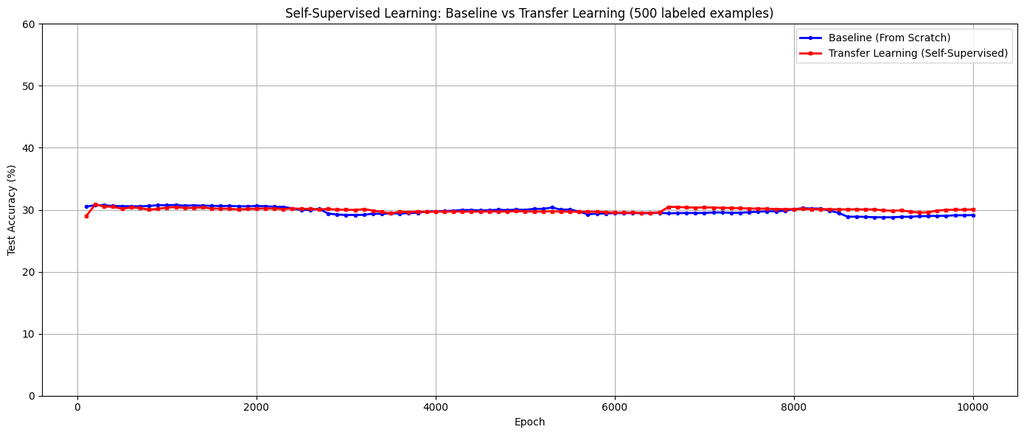

```
================================================================================
SELF-SUPERVISED LEARNING RESULTS
================================================================================
Baseline (From Scratch) - Final Test Accuracy: 29.15%
Transfer Learning - Final Test Accuracy: 30.07%
Improvement: +0.92%

Baseline - Best Test Accuracy: 30.77%
Transfer Learning - Best Test Accuracy: 30.86%
================================================================================
```

```python
# Step 6
epochs_recorded = range(100, num_epochs_baseline + 1, 100)

plt.figure(figsize=(14, 6))

plt.plot(epochs_recorded, test_accuracies_baseline, 'b-', linewidth=2, label='Baseline (From Scratch)', marker='o', markersize=3)
plt.plot(epochs_recorded, test_accuracies_transfer, 'r-', linewidth=2, label='Transfer Learning (Self-Supervised)', marker='s', markersize=3)
plt.xlabel('Epoch')
plt.ylabel('Test Accuracy (%)')
plt.title('Self-Supervised Learning: Baseline vs Transfer Learning (500 labeled examples)')
plt.legend()
plt.grid(True)
plt.ylim([0, 60])

plt.tight_layout()
plt.show()

# Print summary statistics
print("\n" + "="*80)
print("SELF-SUPERVISED LEARNING RESULTS")
print("="*80)
print(f"Baseline (From Scratch) - Final Test Accuracy: {test_accuracies_baseline[-1]:.2f}%")
print(f"Transfer Learning - Final Test Accuracy: {test_accuracies_transfer[-1]:.2f}%")
print(f"Improvement: {test_accuracies_transfer[-1] - test_accuracies_baseline[-1]:+.2f}%")
print(f"\nBaseline - Best Test Accuracy: {max(test_accuracies_baseline):.2f}%")
print(f"Transfer Learning - Best Test Accuracy: {max(test_accuracies_transfer):.2f}%")
print("="*80)
```